# Real-world Data Wrangling

**Fullname:** Nguyen Van Khang

**ID:** 23IT121

**Class:** 23SE2

# **1. Gather data**

# **1.1**. Problem Statement

This project aims to practice my skills of data wrangling using real-world datasets.

The goal of this project is to explore how music trends have changed over time, using Spotify data from 1921 to 2020. The dataset contains various musical features such as tempo, energy, danceability, popularity, genre, and structure-related attributes. By cleaning and analyzing these datasets, I hope to uncover patterns in musical evolution, song popularity, and characteristics of top-performing tracks.

In this dataset, I would like to answer the following research questions:

**Question 1:**  
How does the level of acousticness affect the popularity?

**Question 2:**  
The correlation level between music attributes and popularity?

**Question 3:**  
What is the correlation between song structure attributes (e.g., tempo, loudness, key) and popularity?

**Question 4:**  
How has the average song duration changed over time? Are songs getting shorter or longer?

**Question 5:**  
Do songs with high acousticness tend to be less popular?

# **1.2**. Gather at least two datasets using two different data gathering methods

```python
import numpy as np
import pandas as pd
df = pd.read_csv(r"D:/dataset/messy/data_by_year.csv")
df.head()
```

|  | mode | year | acousticness | danceability | duration_ms | energy | instrumentalness | liveness | loudness | speechiness | tempo | valence | popularity | key |
| --- | --- | --- | --- | --- | --- | --- | --- | --- | --- | --- | --- | --- | --- | --- |
| 0 | 1 | 1921 | 0.886896 | 0.418597 | 260537.166667 | 0.231815 | 0.344878 | 0.205710 | -17.048667 | 0.073662 | 101.531493 | 0.379327 | 0.653333 | 2 |
| 1 | 1 | 1922 | 0.938592 | 0.482042 | 165469.746479 | 0.237815 | 0.434195 | 0.240720 | -19.275282 | 0.116655 | 100.884521 | 0.535549 | 0.140845 | 10 |
| 2 | 1 | 1923 | 0.957247 | 0.577341 | 177942.362162 | 0.262406 | 0.371733 | 0.227462 | -14.129211 | 0.093949 | 114.010730 | 0.625492 | 5.389189 | 0 |
| 3 | 1 | 1924 | 0.940200 | 0.549894 | 191046.707627 | 0.344347 | 0.581701 | 0.235219 | -14.231343 | 0.092089 | 120.689572 | 0.663725 | 0.661017 | 10 |
| 4 | 1 | 1925 | 0.962607 | 0.573863 | 184986.924460 | 0.278594 | 0.418297 | 0.237668 | -14.146414 | 0.111918 | 115.521921 | 0.621929 | 2.604317 | 5 |

```python
import numpy as np
import pandas as pd
df1 = pd.read_csv(r"D:/dataset/messy/music_attributes.csv")
df1.head()
```

|  | artists | id | name | valence | acousticness | danceability | energy | instrumentalness | liveness | speechiness | loudness | tempo |
| --- | --- | --- | --- | --- | --- | --- | --- | --- | --- | --- | --- | --- |
| 0 | ['Sergei Rachmaninoff', 'James Levine', 'Berli... | 4BJqT0PrAfrxzMOxytFOIz | Piano Concerto No. 3 in D Minor, Op. 30: III. ... | 0.0594 | 0.982 | 0.279 | 0.211 | 0.878000 | 0.665 | 0.0366 | -20.096 | 80.954 |
| 1 | ['Dennis Day'] | 7xPhfUan2yNtyFG0cUWkt8 | Clancy Lowered the Boom | 0.9630 | 0.732 | 0.819 | 0.341 | 0.000000 | 0.160 | 0.4150 | -12.441 | 60.936 |
| 2 | ['KHP Kridhamardawa Karaton Ngayogyakarta Hadi... | 1o6I8BglA6ylDMrIELygv1 | Gati Bali | 0.0394 | 0.961 | 0.328 | 0.166 | 0.913000 | 0.101 | 0.0339 | -14.850 | 110.339 |
| 3 | ['Frank Parker'] | 3ftBPsC5vPBKxYSee08FDH | Danny Boy | 0.1650 | 0.967 | 0.275 | 0.309 | 0.000028 | 0.381 | 0.0354 | -9.316 | 100.109 |
| 4 | ['Phil Regan'] | 4d6HGyGT8e121BsdKmw9v6 | When Irish Eyes Are Smiling | 0.2530 | 0.957 | 0.418 | 0.193 | 0.000002 | 0.229 | 0.0380 | -10.096 | 101.665 |

```python
import numpy as np
import pandas as pd
df2 = pd.read_csv(r"D:/dataset/messy/structure_and_popularity.csv")
df2.head()
```

|  | artists | id | name | release_date | year | explicit | key | mode | popularity |
| --- | --- | --- | --- | --- | --- | --- | --- | --- | --- |
| 0 | ['Sergei Rachmaninoff', 'James Levine', 'Berli... | 4BJqT0PrAfrxzMOxytFOIz | Piano Concerto No. 3 in D Minor, Op. 30: III. ... | 1921 | 1921 | 0 | 10 | 1 | 4 |
| 1 | ['Dennis Day'] | 7xPhfUan2yNtyFG0cUWkt8 | Clancy Lowered the Boom | 1921 | 1921 | 0 | 7 | 1 | 5 |
| 2 | ['KHP Kridhamardawa Karaton Ngayogyakarta Hadi... | 1o6I8BglA6ylDMrIELygv1 | Gati Bali | 1921 | 1921 | 0 | 3 | 1 | 5 |
| 3 | ['Frank Parker'] | 3ftBPsC5vPBKxYSee08FDH | Danny Boy | 1921 | 1921 | 0 | 5 | 1 | 3 |
| 4 | ['Phil Regan'] | 4d6HGyGT8e121BsdKmw9v6 | When Irish Eyes Are Smiling | 1921 | 1921 | 0 | 3 | 1 | 2 |

# **2. Assess data**

I will assess the data both visually and programmatically to identify any data quality (content) issues and tidiness (structual) issues.

# **Dataset 1 - Data by years**

**Issue 1** - Missing values and completeness

Inspecting the dataframe visually

```python
df.head()
```

|  | mode | year | acousticness | danceability | duration_ms | energy | instrumentalness | liveness | loudness | speechiness | tempo | valence | popularity | key |
| --- | --- | --- | --- | --- | --- | --- | --- | --- | --- | --- | --- | --- | --- | --- |
| 0 | 1 | 1921 | 0.886896 | 0.418597 | 260537.166667 | 0.231815 | 0.344878 | 0.205710 | -17.048667 | 0.073662 | 101.531493 | 0.379327 | 0.653333 | 2 |
| 1 | 1 | 1922 | 0.938592 | 0.482042 | 165469.746479 | 0.237815 | 0.434195 | 0.240720 | -19.275282 | 0.116655 | 100.884521 | 0.535549 | 0.140845 | 10 |
| 2 | 1 | 1923 | 0.957247 | 0.577341 | 177942.362162 | 0.262406 | 0.371733 | 0.227462 | -14.129211 | 0.093949 | 114.010730 | 0.625492 | 5.389189 | 0 |
| 3 | 1 | 1924 | 0.940200 | 0.549894 | 191046.707627 | 0.344347 | 0.581701 | 0.235219 | -14.231343 | 0.092089 | 120.689572 | 0.663725 | 0.661017 | 10 |
| 4 | 1 | 1925 | 0.962607 | 0.573863 | 184986.924460 | 0.278594 | 0.418297 | 0.237668 | -14.146414 | 0.111918 | 115.521921 | 0.621929 | 2.604317 | 5 |

Inspecting the dataframe programmatically

```python
df.info()
df.isnull().sum()
```

```
<class 'pandas.core.frame.DataFrame'>
RangeIndex: 100 entries, 0 to 99
Data columns (total 14 columns):
 #   Column            Non-Null Count  Dtype
---  ------            --------------  -----
 0   mode              100 non-null    int64
 1   year              100 non-null    int64
 2   acousticness      100 non-null    float64
 3   danceability      100 non-null    float64
 4   duration_ms       100 non-null    float64
 5   energy            100 non-null    float64
 6   instrumentalness  100 non-null    float64
 7   liveness          100 non-null    float64
 8   loudness          100 non-null    float64
 9   speechiness       100 non-null    float64
 10  tempo             100 non-null    float64
 11  valence           100 non-null    float64
 12  popularity        100 non-null    float64
 13  key               100 non-null    int64
dtypes: float64(11), int64(3)
memory usage: 11.1 KB
```

```
mode                0
year                0
acousticness        0
danceability        0
duration_ms         0
energy              0
instrumentalness    0
liveness            0
loudness            0
speechiness         0
tempo               0
valence             0
popularity          0
key                 0
dtype: int64
```

**Observations**

- **Size:** The dataset consists of 100 rows and 14 columns, with no missing values (all columns have 100 non-null entries).
- **Data Types:**
  - **Integer Columns (int64):** `mode`, `year`, `key`
  - **Floating-Point Columns (float64):** The remaining columns, typically representing audio features.
- **Observations:**
  - **No Data Type Errors:** The data types are appropriate for the columns.
  - **Year Column:** Currently an integer, but should be converted to a datetime format for easier processing or visualization.
  - **Identifier Column:** No ID column is present. While not mandatory, adding one could be useful for merging or cross-referencing with other datasets.
- **Conclusion:** With no missing values or data type errors, the dataset is generally clean.

**Issue 2** - Checking for Duplicate Rows or Outliers

Inspecting the dataframe programmatically

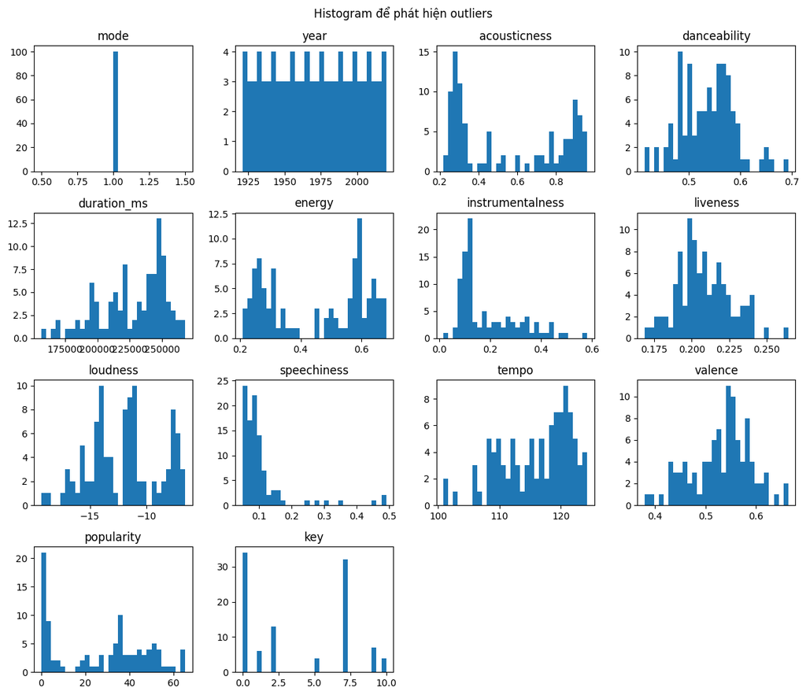

```python
import matplotlib.pyplot as plt
import seaborn as sns
import pandas as pd
import numpy as np
plt.figure(figsize=(12, 6))
# Vẽ histogram cho tất cả các cột số
df.select_dtypes(include=[np.number]).hist(bins=30, figsize=(12, 10), grid=False)
plt.tight_layout()
plt.suptitle("Histogram để phát hiện outliers", y=1.02)
plt.show()
```

```python
df.describe()
```

|  | mode | year | acousticness | danceability | duration_ms | energy | instrumentalness | liveness | loudness | speechiness | tempo | valence | popularity | key |
| --- | --- | --- | --- | --- | --- | --- | --- | --- | --- | --- | --- | --- | --- | --- |
| count | 100.0 | 100.000000 | 100.000000 | 100.000000 | 100.000000 | 100.000000 | 100.000000 | 100.000000 | 100.000000 | 100.000000 | 100.000000 | 100.000000 | 100.000000 | 100.0000 |
| mean | 1.0 | 1970.500000 | 0.556317 | 0.536783 | 227296.752234 | 0.452705 | 0.193582 | 0.208224 | -11.969054 | 0.105861 | 116.015674 | 0.532120 | 27.376065 | 3.7900 |
| std | 0.0 | 29.011492 | 0.275358 | 0.052356 | 25630.048065 | 0.161738 | 0.122488 | 0.017903 | 3.105610 | 0.082128 | 5.669645 | 0.057809 | 20.703197 | 3.5627 |
| min | 1.0 | 1921.000000 | 0.219931 | 0.414445 | 156881.657475 | 0.207948 | 0.016376 | 0.168450 | -19.275282 | 0.049098 | 100.884521 | 0.379327 | 0.140845 | 0.0000 |
| 25% | 1.0 | 1945.750000 | 0.289516 | 0.500800 | 210889.193536 | 0.280733 | 0.103323 | 0.197509 | -14.189232 | 0.064244 | 111.718626 | 0.497174 | 3.298200 | 0.0000 |
| 50% | 1.0 | 1970.500000 | 0.459190 | 0.540976 | 235520.850833 | 0.495997 | 0.127644 | 0.206074 | -11.773061 | 0.085763 | 117.455548 | 0.541503 | 33.619250 | 2.0000 |
| 75% | 1.0 | 1995.250000 | 0.856711 | 0.570948 | 247702.738058 | 0.598008 | 0.276707 | 0.218493 | -9.950542 | 0.104438 | 120.606644 | 0.570080 | 44.943375 | 7.0000 |
| max | 1.0 | 2020.000000 | 0.962607 | 0.692904 | 267677.823086 | 0.681778 | 0.581701 | 0.264335 | -6.595067 | 0.490001 | 124.283129 | 0.663725 | 65.256542 | 10.0000 |

```python
df.duplicated().sum()
```

```
np.int64(0)
```

**Observations**

**Issue 3** - Tidiness and Structural

Inspecting the dataframe visually

```python
df.info()
```

```
<class 'pandas.core.frame.DataFrame'>
RangeIndex: 100 entries, 0 to 99
Data columns (total 14 columns):
 #   Column            Non-Null Count  Dtype
---  ------            --------------  -----
 0   mode              100 non-null    int64
 1   year              100 non-null    int64
 2   acousticness      100 non-null    float64
 3   danceability      100 non-null    float64
 4   duration_ms       100 non-null    float64
 5   energy            100 non-null    float64
 6   instrumentalness  100 non-null    float64
 7   liveness          100 non-null    float64
 8   loudness          100 non-null    float64
 9   speechiness       100 non-null    float64
 10  tempo             100 non-null    float64
 11  valence           100 non-null    float64
 12  popularity        100 non-null    float64
 13  key               100 non-null    int64
dtypes: float64(11), int64(3)
memory usage: 11.1 KB
```

Inspecting the dataframe programmatically

```python
df.info()
df.columns
```

```
<class 'pandas.core.frame.DataFrame'>
RangeIndex: 100 entries, 0 to 99
Data columns (total 14 columns):
 #   Column            Non-Null Count  Dtype
---  ------            --------------  -----
 0   mode              100 non-null    int64
 1   year              100 non-null    int64
 2   acousticness      100 non-null    float64
 3   danceability      100 non-null    float64
 4   duration_ms       100 non-null    float64
 5   energy            100 non-null    float64
 6   instrumentalness  100 non-null    float64
 7   liveness          100 non-null    float64
 8   loudness          100 non-null    float64
 9   speechiness       100 non-null    float64
 10  tempo             100 non-null    float64
 11  valence           100 non-null    float64
 12  popularity        100 non-null    float64
 13  key               100 non-null    int64
dtypes: float64(11), int64(3)
memory usage: 11.1 KB
```

```
Index(['mode', 'year', 'acousticness', 'danceability', 'duration_ms', 'energy',
       'instrumentalness', 'liveness', 'loudness', 'speechiness', 'tempo',
       'valence', 'popularity', 'key'],
      dtype='object')
```

```python
df.duplicated().sum()
```

```
np.int64(0)
```

**Observations**

- The dataset is complete with all necessary information and columns, requiring no further adjustments.

# **Dataset 2 - Data music_attributes**

**Issue 1** - Missing values and completeness

Inspecting the dataframe visually

```python
df1.head()
```

[output not shown]

Inspecting the dataframe programmatically

```python
df.info()
```

```
<class 'pandas.core.frame.DataFrame'>
RangeIndex: 100 entries, 0 to 99
Data columns (total 14 columns):
 #   Column            Non-Null Count  Dtype
---  ------            --------------  -----
 0   mode              100 non-null    int64
 1   year              100 non-null    int64
 2   acousticness      100 non-null    float64
 3   danceability      100 non-null    float64
 4   duration_ms       100 non-null    float64
 5   energy            100 non-null    float64
 6   instrumentalness  100 non-null    float64
 7   liveness          100 non-null    float64
 8   loudness          100 non-null    float64
 9   speechiness       100 non-null    float64
 10  tempo             100 non-null    float64
 11  valence           100 non-null    float64
 12  popularity        100 non-null    float64
 13  key               100 non-null    int64
dtypes: float64(11), int64(3)
memory usage: 11.1 KB
```

```python
df.isnull().sum()
```

```
mode                0
year                0
acousticness        0
danceability        0
duration_ms         0
energy              0
instrumentalness    0
liveness            0
loudness            0
speechiness         0
tempo               0
valence             0
popularity          0
key                 0
dtype: int64
```

```python
df1.shape
```

```
(170653, 12)
```

### **Observations**

#### **Size**

- The dataset consists of 170,653 rows and 12 columns, with no missing values (all columns have 170,653 non-null entries).

#### **Data Types**

- Object Columns:
  - **artists**: list of artist names stored as a string
  - **id, name**: identifiers and song titles
- Floating-Point Columns (float64): **valence, acousticness, danceability, energy, instrumentalness, liveness, speechiness, loudness, tempo**
- Observations:
  - No Missing Values: All columns are fully populated.

#### **Data Types Are Appropriate**

- Identifiers and descriptive fields are stored as strings.
- Audio feature columns are correctly typed as floats for quantitative analysis.

##### **Artists Column**

- The artists column contains list-like strings. For deeper analysis (e.g., frequency of appearances), this should be normalized or exploded.

##### **No Time-Based Column Present**

- There is no column such as year or release_date. This limits the ability to perform time-series analysis or observe historical trends.

#### **Conclusion:**

The dataset is large, clean, and well-structured, with no data type errors or missing values.

**Issue 2** - Checking for Duplicate Rows or Outliers

Inspecting the dataframe programmatically

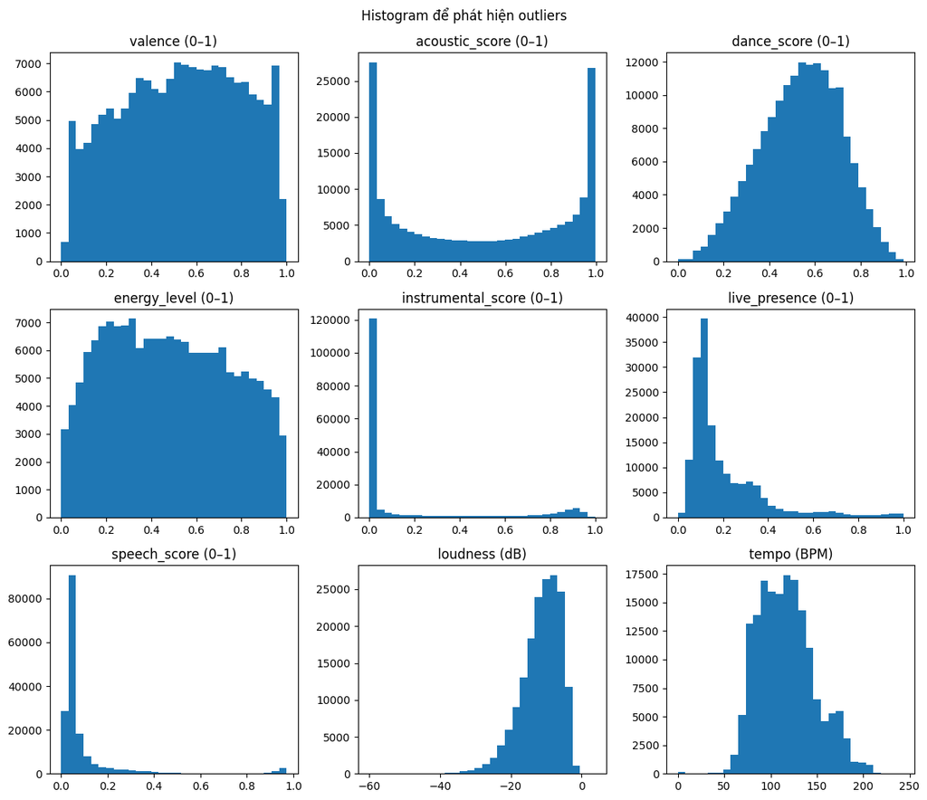

```python
import matplotlib.pyplot as plt
import seaborn as sns
import pandas as pd
import numpy as np

# Nếu chưa có, hãy thay bằng tên DataFrame thực tế của bạn
plt.figure(figsize=(12, 6))

# Vẽ histogram cho tất cả các cột số
df1.select_dtypes(include=[np.number]).hist(bins=30, figsize=(12, 10), grid=False)
plt.tight_layout()
plt.suptitle("Histogram để phát hiện outliers", y=1.02)
plt.show()
```

```python
df1.describe()
```

[output not shown]

```python
df1.duplicated().sum()
```

```
np.int64(0)
```

**Observations**

**Issue 3** - Tidiness and Structural

Inspecting the dataframe visually

```python
df1.info()
```

[output not shown]

```python
df1.columns
```

[output not shown]

```python
df1.duplicated().sum()
```

```
np.int64(0)
```

**Observations**

- The dataset is complete with all necessary information and columns, requiring no further adjustments.

# **Dataset 3 - Data Structure and Popularity**

**Issue 1** - Missing values and completeness

Inspecting the dataframe visually

```python
df2.head()
```

[output not shown]

```python
df2.info()
```

[output not shown]

```python
df2.isnull().sum()
```

[output not shown]

```python
df2.shape
```

```
(170653, 9)
```

# **Observations**

- Size: The dataset consists of 170,653 rows and 9 columns, with no missing values (all columns have 170,653 non-null entries).
- Data Types:
  - Integer Columns (int64): **year, explicit, key, mode, popularity**
  - Object Columns (object): **artists, id, name, release_date**
- Observations:
  - No Missing Values: All entries are complete.
  - **release_date** Column: Currently stored as object (string); converting it to datetime format would enable more advanced temporal analysis.
  - **explicit** Column: Encoded as integers (likely 0 = not explicit, 1 = explicit); consider converting to boolean for clarity.
  - **Artists** Column: Stored as list-like string, which may require parsing (e.g., with ast.literal_eval) to access individual artist names.
  - **ID** Column: Useful as a unique identifier for each track; no duplicates observed in provided sample.
- Conclusion: The dataset is large, clean, and well-structured.

**Issue 2** - Checking for Duplicate Rows or Outliers

Inspecting the dataframe programmatically

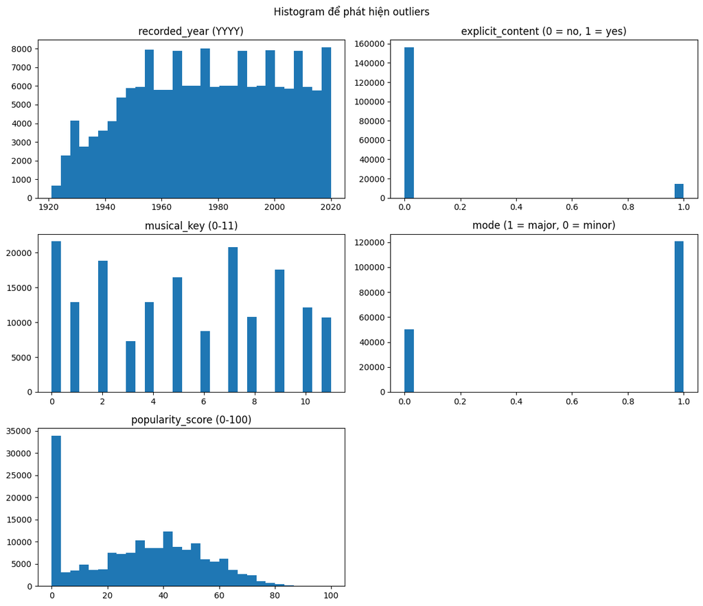

```python
import matplotlib.pyplot as plt
import seaborn as sns
import pandas as pd
import numpy as np

# Nếu chưa có, hãy thay bằng tên DataFrame thực tế của bạn
plt.figure(figsize=(12, 6))

# Vẽ histogram cho tất cả các cột số
df2.select_dtypes(include=[np.number]).hist(bins=30, figsize=(12, 10), grid=False)
plt.tight_layout()
plt.suptitle("Histogram để phát hiện outliers", y=1.02)
plt.show()
```

```python
df2.describe()
```

[output not shown]

```python
df2.duplicated().sum()
```

```
np.int64(0)
```

## **Observations**

**Issue 3** - Tidiness and Structural

Inspecting the dataframe visually

```python
df2.info()
```

[output not shown]

```python
df2.columns
```

[output not shown]

```python
df.duplicated().sum()
```

```
np.int64(0)
```

**Observations**

- The dataset is complete with all necessary information and columns, requiring no further adjustments.

# **3. Clean data**

Clean the data to solve the 4 issues corresponding to data quality and tidiness found in the assessing step.

# **Dataset 1 - Data by years**

**Issue 1** - Round to 3 decimal places

```python
import numpy as np
import pandas as pd
df = pd.read_csv(r"D:/dataset/messy/data_by_year.csv")
df = df.round(3)
df.head()
```

|  | mode | year | acousticness | danceability | duration_ms | energy | instrumentalness | liveness | loudness | speechiness | tempo | valence | popularity | key |
| --- | --- | --- | --- | --- | --- | --- | --- | --- | --- | --- | --- | --- | --- | --- |
| 0 | 1 | 1921 | 0.887 | 0.419 | 260537.167 | 0.232 | 0.345 | 0.206 | -17.049 | 0.074 | 101.531 | 0.379 | 0.653 | 2 |
| 1 | 1 | 1922 | 0.939 | 0.482 | 165469.746 | 0.238 | 0.434 | 0.241 | -19.275 | 0.117 | 100.885 | 0.536 | 0.141 | 10 |
| 2 | 1 | 1923 | 0.957 | 0.577 | 177942.362 | 0.262 | 0.372 | 0.227 | -14.129 | 0.094 | 114.011 | 0.625 | 5.389 | 0 |
| 3 | 1 | 1924 | 0.940 | 0.550 | 191046.708 | 0.344 | 0.582 | 0.235 | -14.231 | 0.092 | 120.690 | 0.664 | 0.661 | 10 |
| 4 | 1 | 1925 | 0.963 | 0.574 | 184986.924 | 0.279 | 0.418 | 0.238 | -14.146 | 0.112 | 115.522 | 0.622 | 2.604 | 5 |

**Issue 2** - Convert the values in the `duration_ms` column to minutes.

```python
df["duration_ms"] = (df["duration_ms"] / 60000).round(3)
df.rename(columns={"duration_ms": "duration_min"}, inplace=True)
df.head()
```

|  | mode | year | acousticness | danceability | duration_min | energy | instrumentalness | liveness | loudness | speechiness | tempo | valence | popularity | key |
| --- | --- | --- | --- | --- | --- | --- | --- | --- | --- | --- | --- | --- | --- | --- |
| 0 | 1 | 1921 | 0.887 | 0.419 | 4.342 | 0.232 | 0.345 | 0.206 | -17.049 | 0.074 | 101.531 | 0.379 | 0.653 | 2 |
| 1 | 1 | 1922 | 0.939 | 0.482 | 2.758 | 0.238 | 0.434 | 0.241 | -19.275 | 0.117 | 100.885 | 0.536 | 0.141 | 10 |
| 2 | 1 | 1923 | 0.957 | 0.577 | 2.966 | 0.262 | 0.372 | 0.227 | -14.129 | 0.094 | 114.011 | 0.625 | 5.389 | 0 |
| 3 | 1 | 1924 | 0.940 | 0.550 | 3.184 | 0.344 | 0.582 | 0.235 | -14.231 | 0.092 | 120.690 | 0.664 | 0.661 | 10 |
| 4 | 1 | 1925 | 0.963 | 0.574 | 3.083 | 0.279 | 0.418 | 0.238 | -14.146 | 0.112 | 115.522 | 0.622 | 2.604 | 5 |

**Issue 3** - Column Naming for Clarity and Consistency

```python
df.rename(columns={
    'mode': 'musical_mode',
    'key': 'musical_key',
    'valence': 'positiveness_score',
    'danceability': 'danceability_score',
    'energy': 'energy_level',
    'liveness': 'live_presence',
    'speechiness': 'speech_content',
    'instrumentalness': 'instrumental_ratio',
    'acousticness': 'acoustic_ratio',
    'duration_min': 'duration_minutes'
}, inplace=True)
df.head()
```

|  | musical_mode | year | acoustic_ratio | danceability_score | duration_minutes | energy_level | instrumental_ratio | live_presence | loudness | speech_content | tempo | positiveness_score | popularity | musical_key |
| --- | --- | --- | --- | --- | --- | --- | --- | --- | --- | --- | --- | --- | --- | --- |
| 0 | 1 | 1921 | 0.887 | 0.419 | 4.342 | 0.232 | 0.345 | 0.206 | -17.049 | 0.074 | 101.531 | 0.379 | 0.653 | 2 |
| 1 | 1 | 1922 | 0.939 | 0.482 | 2.758 | 0.238 | 0.434 | 0.241 | -19.275 | 0.117 | 100.885 | 0.536 | 0.141 | 10 |
| 2 | 1 | 1923 | 0.957 | 0.577 | 2.966 | 0.262 | 0.372 | 0.227 | -14.129 | 0.094 | 114.011 | 0.625 | 5.389 | 0 |
| 3 | 1 | 1924 | 0.940 | 0.550 | 3.184 | 0.344 | 0.582 | 0.235 | -14.231 | 0.092 | 120.690 | 0.664 | 0.661 | 10 |
| 4 | 1 | 1925 | 0.963 | 0.574 | 3.083 | 0.279 | 0.418 | 0.238 | -14.146 | 0.112 | 115.522 | 0.622 | 2.604 | 5 |

**Issue 4** - Convert year Column to Datetime Format

```python
df['year'] = pd.to_datetime(df['year'], format='%Y')
df['year'] = df['year'].dt.year
df.head()
```

|  | musical_mode | year | acoustic_ratio | danceability_score | duration_minutes | energy_level | instrumental_ratio | live_presence | loudness | speech_content | tempo | positiveness_score | popularity | musical_key |
| --- | --- | --- | --- | --- | --- | --- | --- | --- | --- | --- | --- | --- | --- | --- |
| 0 | 1 | 1921 | 0.887 | 0.419 | 4.342 | 0.232 | 0.345 | 0.206 | -17.049 | 0.074 | 101.531 | 0.379 | 0.653 | 2 |
| 1 | 1 | 1922 | 0.939 | 0.482 | 2.758 | 0.238 | 0.434 | 0.241 | -19.275 | 0.117 | 100.885 | 0.536 | 0.141 | 10 |
| 2 | 1 | 1923 | 0.957 | 0.577 | 2.966 | 0.262 | 0.372 | 0.227 | -14.129 | 0.094 | 114.011 | 0.625 | 5.389 | 0 |
| 3 | 1 | 1924 | 0.940 | 0.550 | 3.184 | 0.344 | 0.582 | 0.235 | -14.231 | 0.092 | 120.690 | 0.664 | 0.661 | 10 |
| 4 | 1 | 1925 | 0.963 | 0.574 | 3.083 | 0.279 | 0.418 | 0.238 | -14.146 | 0.112 | 115.522 | 0.622 | 2.604 | 5 |

# **Dataset 2 - Music Attributes**

**Issue 1** - Round to 3 decimal places

```python
import numpy as np
import pandas as pd
df1 = pd.read_csv(r"D:/dataset/messy/music_attributes.csv")
df1 = df1.round(3)
df1.head()
```

|  | artists | id | name | valence | acousticness | danceability | energy | instrumentalness | liveness | speechiness | loudness | tempo |
| --- | --- | --- | --- | --- | --- | --- | --- | --- | --- | --- | --- | --- |
| 0 | ['Sergei Rachmaninoff', 'James Levine', 'Berli... | 4BJqT0PrAfrxzMOxytFOIz | Piano Concerto No. 3 in D Minor, Op. 30: III. ... | 0.059 | 0.982 | 0.279 | 0.211 | 0.878 | 0.665 | 0.037 | -20.096 | 80.954 |
| 1 | ['Dennis Day'] | 7xPhfUan2yNtyFG0cUWkt8 | Clancy Lowered the Boom | 0.963 | 0.732 | 0.819 | 0.341 | 0.000 | 0.160 | 0.415 | -12.441 | 60.936 |
| 2 | ['KHP Kridhamardawa Karaton Ngayogyakarta Hadi... | 1o6I8BglA6ylDMrIELygv1 | Gati Bali | 0.039 | 0.961 | 0.328 | 0.166 | 0.913 | 0.101 | 0.034 | -14.850 | 110.339 |
| 3 | ['Frank Parker'] | 3ftBPsC5vPBKxYSee08FDH | Danny Boy | 0.165 | 0.967 | 0.275 | 0.309 | 0.000 | 0.381 | 0.035 | -9.316 | 100.109 |
| 4 | ['Phil Regan'] | 4d6HGyGT8e121BsdKmw9v6 | When Irish Eyes Are Smiling | 0.253 | 0.957 | 0.418 | 0.193 | 0.000 | 0.229 | 0.038 | -10.096 | 101.665 |

**Issue 2** - Format the artists column

```python
import pandas as pd
import ast
df1 = pd.read_csv(r"D:/dataset/messy/music_attributes.csv")
# Định nghĩa hàm format_artists_column để xử lý cột nghệ sĩ trong dataframe
def format_artists_column(df1, col_name='artists'):
    # Áp dụng cho từng giá trị trong cột col_name (mặc định là 'artists')
    # Với mỗi giá trị x (chuỗi dạng danh sách nghệ sĩ)
    df1[col_name] = df1[col_name].apply(
        lambda x:
            # Chuyển chuỗi x thành list Python thực sự, ví dụ: "['A', 'B']" -> ['A', 'B']
            ast.literal_eval(x)
    # Nối các phần tử trong list thành chuỗi, ngăn cách bằng dấu phẩy và khoảng trắng
    ).apply(lambda lst: ", ".join(lst))

    # Trả về dataframe đã được chỉnh sửa cột artists
    return df1
df1 = format_artists_column(df1, 'artists')
df1.head()
```

|  | artists | id | name | valence | acousticness | danceability | energy | instrumentalness | liveness | speechiness | loudness | tempo |
| --- | --- | --- | --- | --- | --- | --- | --- | --- | --- | --- | --- | --- |
| 0 | Sergei Rachmaninoff, James Levine, Berliner Ph... | 4BJqT0PrAfrxzMOxytFOIz | Piano Concerto No. 3 in D Minor, Op. 30: III. ... | 0.0594 | 0.982 | 0.279 | 0.211 | 0.878000 | 0.665 | 0.0366 | -20.096 | 80.954 |
| 1 | Dennis Day | 7xPhfUan2yNtyFG0cUWkt8 | Clancy Lowered the Boom | 0.9630 | 0.732 | 0.819 | 0.341 | 0.000000 | 0.160 | 0.4150 | -12.441 | 60.936 |
| 2 | KHP Kridhamardawa Karaton Ngayogyakarta Hadini... | 1o6I8BglA6ylDMrIELygv1 | Gati Bali | 0.0394 | 0.961 | 0.328 | 0.166 | 0.913000 | 0.101 | 0.0339 | -14.850 | 110.339 |
| 3 | Frank Parker | 3ftBPsC5vPBKxYSee08FDH | Danny Boy | 0.1650 | 0.967 | 0.275 | 0.309 | 0.000028 | 0.381 | 0.0354 | -9.316 | 100.109 |
| 4 | Phil Regan | 4d6HGyGT8e121BsdKmw9v6 | When Irish Eyes Are Smiling | 0.2530 | 0.957 | 0.418 | 0.193 | 0.000002 | 0.229 | 0.0380 | -10.096 | 101.665 |

**Issue 3** - Column Naming for Clarity and Consistency

```python
# Đổi tên các cột trong DataFrame df1 để rõ ràng hơn về phạm vi hoặc đơn vị đo
df1 = df1.rename(columns={
    'valence': 'valence (0–1)',
    'acousticness': 'acoustic_score (0–1)',
    'danceability': 'dance_score (0–1)',
    'energy': 'energy_level (0–1)',
    'instrumentalness': 'instrumental_score (0–1)',
    'liveness': 'live_presence (0–1)',
    'speechiness': 'speech_score (0–1)',
    'loudness': 'loudness (dB)',
    'tempo': 'tempo (BPM)'
})

df1.head()
```

|  | artists | id | name | valence (0–1) | acoustic_score (0–1) | dance_score (0–1) | energy_level (0–1) | instrumental_score (0–1) | live_presence (0–1) | speech_score (0–1) | loudness (dB) | tempo (BPM) |
| --- | --- | --- | --- | --- | --- | --- | --- | --- | --- | --- | --- | --- |
| 0 | Sergei Rachmaninoff, James Levine, Berliner Ph... | 4BJqT0PrAfrxzMOxytFOIz | Piano Concerto No. 3 in D Minor, Op. 30: III. ... | 0.0594 | 0.982 | 0.279 | 0.211 | 0.878000 | 0.665 | 0.0366 | -20.096 | 80.954 |
| 1 | Dennis Day | 7xPhfUan2yNtyFG0cUWkt8 | Clancy Lowered the Boom | 0.9630 | 0.732 | 0.819 | 0.341 | 0.000000 | 0.160 | 0.4150 | -12.441 | 60.936 |
| 2 | KHP Kridhamardawa Karaton Ngayogyakarta Hadini... | 1o6I8BglA6ylDMrIELygv1 | Gati Bali | 0.0394 | 0.961 | 0.328 | 0.166 | 0.913000 | 0.101 | 0.0339 | -14.850 | 110.339 |
| 3 | Frank Parker | 3ftBPsC5vPBKxYSee08FDH | Danny Boy | 0.1650 | 0.967 | 0.275 | 0.309 | 0.000028 | 0.381 | 0.0354 | -9.316 | 100.109 |
| 4 | Phil Regan | 4d6HGyGT8e121BsdKmw9v6 | When Irish Eyes Are Smiling | 0.2530 | 0.957 | 0.418 | 0.193 | 0.000002 | 0.229 | 0.0380 | -10.096 | 101.665 |

# **Dataset 3 - Music Structure and popularity**

```python
import numpy as np
import pandas as pd
df2 = pd.read_csv(r"D:/dataset/messy/structure_and_popularity.csv")
df2.head()
```

|  | artists | id | name | release_date | year | explicit | key | mode | popularity |
| --- | --- | --- | --- | --- | --- | --- | --- | --- | --- |
| 0 | ['Sergei Rachmaninoff', 'James Levine', 'Berli... | 4BJqT0PrAfrxzMOxytFOIz | Piano Concerto No. 3 in D Minor, Op. 30: III. ... | 1921 | 1921 | 0 | 10 | 1 | 4 |
| 1 | ['Dennis Day'] | 7xPhfUan2yNtyFG0cUWkt8 | Clancy Lowered the Boom | 1921 | 1921 | 0 | 7 | 1 | 5 |
| 2 | ['KHP Kridhamardawa Karaton Ngayogyakarta Hadi... | 1o6I8BglA6ylDMrIELygv1 | Gati Bali | 1921 | 1921 | 0 | 3 | 1 | 5 |
| 3 | ['Frank Parker'] | 3ftBPsC5vPBKxYSee08FDH | Danny Boy | 1921 | 1921 | 0 | 5 | 1 | 3 |
| 4 | ['Phil Regan'] | 4d6HGyGT8e121BsdKmw9v6 | When Irish Eyes Are Smiling | 1921 | 1921 | 0 | 3 | 1 | 2 |

**Issue 2** - Format the artists column

```python
import pandas as pd           # Nhập thư viện pandas để xử lý dữ liệu dạng bảng
import ast                    # Nhập thư viện ast để chuyển chuỗi sang đối tượng Python

# Định nghĩa hàm format_artists_column để xử lý định dạng của cột 'artists' trong DataFrame
def format_artists_column(df2, col_name='artists'):
    # Áp dụng 2 bước xử lý liên tiếp cho từng phần tử x trong cột col_name:
    df2[col_name] = df2[col_name].apply(
        lambda x:
            ast.literal_eval(x)   # Bước 1: Chuyển chuỗi mô tả danh sách thành list Python thực (ví dụ: "['A', 'B']" -> ['A', 'B'])
    ).apply(
        lambda lst: ", ".join(lst)  # Bước 2: Ghép các phần tử của list thành chuỗi, ngăn cách bằng dấu phẩy và khoảng trắng
    )

    # Trả về DataFrame sau khi đã chỉnh sửa cột artists
    return df2

# Xem trước 5 dòng đầu tiên của DataFrame sau khi chạy hàm (nếu đã gọi hàm ở đâu đó)
df2 = format_artists_column(df2)
df2.head()
```

[output not shown]

**Issue 3** - Column Naming for Clarity and Consistency

```python
import pandas as pd
df2 = pd.read_csv(r"D:/dataset/messy/structure_and_popularity.csv")

df2.rename(columns={
    'release_date': 'release_year (YYYY)',
    'year': 'recorded_year (YYYY)',
    'explicit': 'explicit_content (0 = no, 1 = yes)',
    'key': 'musical_key (0-11)',
    'mode': 'mode (1 = major, 0 = minor)',
    'popularity': 'popularity_score (0-100)'
}, inplace=True)
df2 = format_artists_column(df2)
df2.head()
```

|  | artists | id | name | release_year (YYYY) | recorded_year (YYYY) | explicit_content (0 = no, 1 = yes) | musical_key (0-11) | mode (1 = major, 0 = minor) | popularity_score (0-100) |
| --- | --- | --- | --- | --- | --- | --- | --- | --- | --- |
| 0 | Sergei Rachmaninoff, James Levine, Berliner Ph... | 4BJqT0PrAfrxzMOxytFOIz | Piano Concerto No. 3 in D Minor, Op. 30: III. ... | 1921 | 1921 | 0 | 10 | 1 | 4 |
| 1 | Dennis Day | 7xPhfUan2yNtyFG0cUWkt8 | Clancy Lowered the Boom | 1921 | 1921 | 0 | 7 | 1 | 5 |
| 2 | KHP Kridhamardawa Karaton Ngayogyakarta Hadini... | 1o6I8BglA6ylDMrIELygv1 | Gati Bali | 1921 | 1921 | 0 | 3 | 1 | 5 |
| 3 | Frank Parker | 3ftBPsC5vPBKxYSee08FDH | Danny Boy | 1921 | 1921 | 0 | 5 | 1 | 3 |
| 4 | Phil Regan | 4d6HGyGT8e121BsdKmw9v6 | When Irish Eyes Are Smiling | 1921 | 1921 | 0 | 3 | 1 | 2 |

**Merge 2 Dataset**

```python
# Đảm bảo df1 đã được định nghĩa và làm sạch
if 'df1' not in globals():
	import pandas as pd
	import ast
	df1 = pd.read_csv(r"D:/dataset/messy/music_attributes.csv")
	# Làm sạch cột artists
	def format_artists_column(df1, col_name='artists'):
		df1[col_name] = df1[col_name].apply(
			lambda x: ast.literal_eval(x)
		).apply(lambda lst: ", ".join(lst))
		return df1
	df1 = format_artists_column(df1, 'artists')
	# Đổi tên các cột cho nhất quán với các cell trước
	df1 = df1.rename(columns={
		'valence': 'valence (0–1)',
		'acousticness': 'acoustic_score (0–1)',
		'danceability': 'dance_score (0–1)',
		'energy': 'energy_level (0–1)',
		'instrumentalness': 'instrumental_score (0–1)',
		'liveness': 'live_presence (0–1)',
		'speechiness': 'speech_score (0–1)',
		'loudness': 'loudness (dB)',
		'tempo': 'tempo (BPM)'
	})
	df1 = df1.round(3)

# Sử dụng df2 và df1 đã được làm sạch ở các cell trước để merge
merged_df = pd.merge(df2, df1, on=['artists', 'id', 'name'], how='inner')
merged_df.head()
```

|  | artists | id | name | release_year (YYYY) | recorded_year (YYYY) | explicit_content (0 = no, 1 = yes) | musical_key (0-11) | mode (1 = major, 0 = minor) | popularity_score (0-100) | valence (0–1) | acoustic_score (0–1) | dance_score (0–1) | energy_level (0–1) | instrumental_score (0–1) | live_presence (0–1) | speech_score (0–1) | loudness (dB) | tempo (BPM) |
| --- | --- | --- | --- | --- | --- | --- | --- | --- | --- | --- | --- | --- | --- | --- | --- | --- | --- | --- |
| 0 | Sergei Rachmaninoff, James Levine, Berliner Ph... | 4BJqT0PrAfrxzMOxytFOIz | Piano Concerto No. 3 in D Minor, Op. 30: III. ... | 1921 | 1921 | 0 | 10 | 1 | 4 | 0.059 | 0.982 | 0.279 | 0.211 | 0.878 | 0.665 | 0.037 | -20.096 | 80.954 |
| 1 | Dennis Day | 7xPhfUan2yNtyFG0cUWkt8 | Clancy Lowered the Boom | 1921 | 1921 | 0 | 7 | 1 | 5 | 0.963 | 0.732 | 0.819 | 0.341 | 0.000 | 0.160 | 0.415 | -12.441 | 60.936 |
| 2 | KHP Kridhamardawa Karaton Ngayogyakarta Hadini... | 1o6I8BglA6ylDMrIELygv1 | Gati Bali | 1921 | 1921 | 0 | 3 | 1 | 5 | 0.039 | 0.961 | 0.328 | 0.166 | 0.913 | 0.101 | 0.034 | -14.850 | 110.339 |
| 3 | Frank Parker | 3ftBPsC5vPBKxYSee08FDH | Danny Boy | 1921 | 1921 | 0 | 5 | 1 | 3 | 0.165 | 0.967 | 0.275 | 0.309 | 0.000 | 0.381 | 0.035 | -9.316 | 100.109 |
| 4 | Phil Regan | 4d6HGyGT8e121BsdKmw9v6 | When Irish Eyes Are Smiling | 1921 | 1921 | 0 | 3 | 1 | 2 | 0.253 | 0.957 | 0.418 | 0.193 | 0.000 | 0.229 | 0.038 | -10.096 | 101.665 |

# **4. Update data store**

```python
# Lưu DataFrame ra file CSV
merged_df.to_csv('merged_data.csv', index=False)

# Lưu DataFrame ra file HTML
merged_df.to_html('merged_data.html', index=False)
```

# **5. Answer the research question**

# **Nguyễn Văn Khang**

**Question 1:**  
How does the level of acousticness affect the popularity?

Mức độ acousticness (tính mộc, ít nhạc điện tử) ảnh hưởng như thế nào đến mức độ phổ biến của bài hát?

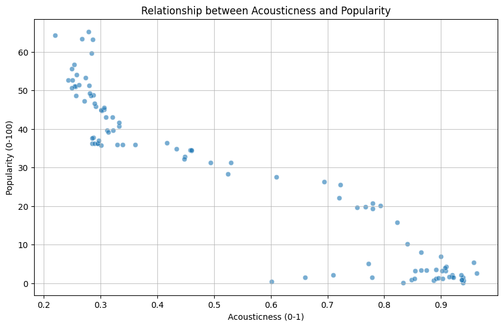

```
Correlation: -0.95
```

```python
import matplotlib.pyplot as plt
import seaborn as sns
df = pd.read_csv(r"D:/dataset/messy/data_by_year.csv")
df.head()
def analyze_acousticness_vs_popularity(df):
    # Tạo hình vẽ với kích thước 10x6
    plt.figure(figsize=(10, 6))
    # Đổi tên cột cho đồng nhất
    df.rename(columns={"acoustic_ratio": "acousticness"}, inplace=True)##
    # Vẽ biểu đồ scatter với độ trong suốt (alpha) là 0.6
    sns.scatterplot(data=df, x='acousticness', y='popularity', alpha=0.6)##
    # Đặt tiêu đề cho biểu đồ
    plt.title('Relationship between Acousticness and Popularity')
    # Đặt nhãn cho trục x
    plt.xlabel('Acousticness (0-1)')
    # Đặt nhãn cho trục y
    plt.ylabel('Popularity (0-100)')
    # Thêm lưới với độ trong suốt 0.7
    plt.grid(True, alpha=0.7)
    # Hiển thị biểu đồ
    plt.show()
    # Tính và in hệ số tương quan giữa acousticness và popularity
    correlation = df['acousticness'].corr(df['popularity'])##
    print(f"Correlation: {correlation:.2f}")

# Gọi hàm để phân tích dữ liệu từ DataFrame df
analyze_acousticness_vs_popularity(df)
```

### Q1. Mối Quan Hệ Giữa Độ Acoustic và Mức Độ Phổ Biến

1. **Xu Hướng Âm Nhạc Hiện Đại Ảnh Hưởng Đến Độ Acoustic**
   - Các bài hát acoustic — sử dụng nhạc cụ tự nhiên như guitar, piano và ít xử lý điện tử — thường xuất hiện trong các thể loại cổ điển, dân ca hoặc ballad cổ.
   - Tuy nhiên, xu hướng âm nhạc hiện nay nghiêng nhiều về pop điện tử, hip-hop và EDM, vốn có độ acoustic thấp do sử dụng âm thanh tổng hợp và sản xuất phức tạp.
2. **Các Bài Hát Có Độ Acoustic Thấp Thường Được Ưa Chuộng Hơn**
   - Biểu đồ scatter cho thấy những bài hát có độ acoustic thấp thường đạt điểm phổ biến cao hơn — điều này phản ánh đúng xu hướng tiêu dùng âm nhạc hiện nay.
   - Các bảng xếp hạng như Billboard hay Spotify Top 50 hiếm khi có mặt những ca khúc thuần acoustic.
   - Ngay cả các nghệ sĩ nổi tiếng với phong cách acoustic (ví dụ: Taylor Swift, Ed Sheeran) cũng đã dần chuyển hướng sang electro-pop để duy trì sự phổ biến.
3. **Các Bài Hát Có Độ Acoustic Cao Thường Thuộc Dòng Nhạc Kén Người Nghe hoặc Cổ Điển**
   - Các bài hát có độ acoustic cao (gần 1.0) thường là:
     - Tác phẩm cổ điển (ví dụ: Rachmaninoff, Bach),
     - Nhạc dân gian truyền thống,
     - Hoặc các bản ghi âm acoustic trực tiếp.
   - Những thể loại này thường không phản ánh thị hiếu của số đông, giải thích vì sao chúng có mức độ phổ biến thấp dù mang nhiều giá trị nghệ thuật.
4. **Vẫn Tồn Tại Những Ngoại Lệ**
   - Mặc dù độ acoustic cao thường gắn với mức độ phổ biến thấp, vẫn có những ngoại lệ đáng chú ý:
     - Ví dụ: “Someone Like You” của Adele hoặc “Photograph” của Ed Sheeran — đều là những ca khúc thiên về acoustic nhưng vẫn đạt được thành công thương mại lớn.
   - Những ca khúc này thành công phần lớn nhờ vào thương hiệu nghệ sĩ và chiến lược marketing mạnh mẽ, không chỉ bởi phong cách âm nhạc.
5. **Bài Học Thực Tiễn Từ Phân Tích**
   - Với các nhạc sĩ hoặc nhà sản xuất, việc hiểu rằng những ca khúc mang tính điện tử, dễ nhảy theo có khả năng thành công cao trên thị trường hiện nay là rất quan trọng.
   - Tuy nhiên, âm nhạc không chỉ là chạy theo xu hướng — các bài hát mang phong cách acoustic vẫn có một cộng đồng người nghe trung thành, đặc biệt trong giới indie, các buổi biểu diễn trực tiếp và dòng nhạc thư giãn.

**Question 2:**  
The correlation level between music attributes and popularity?

Mức độ tương quan giữa các thuộc tính âm nhạc và mức độ phổ biến đề cập đến việc mỗi đặc điểm âm nhạc có liên quan như thế nào đến độ phổ biến của một bài hát.

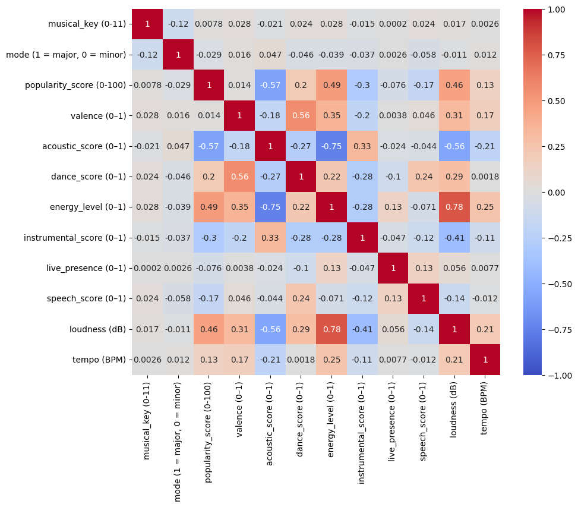

```python
import matplotlib.pyplot as plt
import seaborn as sns

# Select music attribute columns
cols = ['musical_key (0-11)', 'mode (1 = major, 0 = minor)', 'popularity_score (0-100)',
        'valence (0–1)', 'acoustic_score (0–1)', 'dance_score (0–1)', 'energy_level (0–1)',
        'instrumental_score (0–1)', 'live_presence (0–1)', 'speech_score (0–1)',
        'loudness (dB)', 'tempo (BPM)']

# Tạo biểu đồ heatmap để hiển thị ma trận tương quan giữa các thuộc tính
plt.figure(figsize=(10, 8))  # Thiết lập kích thước của biểu đồ
sns.heatmap(
    merged_df[cols].dropna().corr(),             # Tính ma trận tương quan sau khi loại bỏ giá trị thiếu
    annot=True,                                  # Hiển thị giá trị số trên từng ô
    cmap='coolwarm',                             # Bảng màu từ xanh lạnh đến đỏ nóng
    center=0,                                    # Trung tâm của bảng màu là 0
    vmin=-1, vmax=1                              # Giới hạn giá trị tương quan từ -1 đến 1
)
```

## **Q2 - Nhận Xét Thực Tế Về Biểu Đồ Nhiệt (Correlation Heatmap)**

Biểu đồ nhiệt cho thấy mối tương quan tuyến tính giữa các đặc trưng âm nhạc và độ phổ biến (`popularity_score`). Dưới đây là những phân tích thực tiễn:

### 2. Các Mối Quan Hệ Đáng Chú Ý Giữa Các Thuộc Tính

- **Energy_level** và **loudness (0.78)** gần như song hành: Nhạc mạnh thường đi với âm lượng lớn.  
  → Đây là tiêu chuẩn trong sản xuất nhạc pop/EDM hiện nay: tăng “impact” để thu hút người nghe ngay từ những giây đầu.
- **Acoustic_score** có tương quan âm mạnh với cả **energy_level (-0.75)** và **loudness (-0.56)**.  
  → Nhạc acoustic vốn nhẹ nhàng, ít xử lý nên khó cạnh tranh trong môi trường streaming khi người nghe dễ bị phân tâm.
- **Dance_score** và **valence (0.56)** có tương quan dương: Bài dễ nhảy thường mang đến cảm xúc tích cực.  
  → Phù hợp với xu hướng “nhạc giải trí” phục vụ mạng xã hội (TikTok, Instagram Reels) — nơi nhạc vui nhộn lan truyền nhanh hơn.

### 3. Các Thuộc Tính Có Ảnh Hưởng Thấp

- Những yếu tố như **giọng nhạc (musical_key)**, **mode**, **tempo**, hoặc **live_presence** có tương quan rất yếu với độ phổ biến.  
  → Nghĩa là việc chọn nhịp độ nhanh/chậm, giọng trưởng/thứ không quyết định thành công của bài hát. Người nghe hiện đại quan tâm đến **tổng thể cảm xúc và độ bắt tai** hơn là lý thuyết âm nhạc.

## **Question 3**

- What is the correlation between song structure attributes (e.g., tempo, loudness, key) and popularity?
- Mối tương quan giữa các thuộc tính cấu trúc bài hát (ví dụ: nhịp độ (tempo), độ lớn (loudness), tông (key)) và mức độ phổ biến là gì?

```
Correlation matrix:
               tempo  loudness       key  popularity
tempo       1.000000  0.853266  0.021341    0.843231
loudness    0.853266  1.000000 -0.020220    0.928369
key         0.021341 -0.020220  1.000000   -0.053469
popularity  0.843231  0.928369 -0.053469    1.000000
```

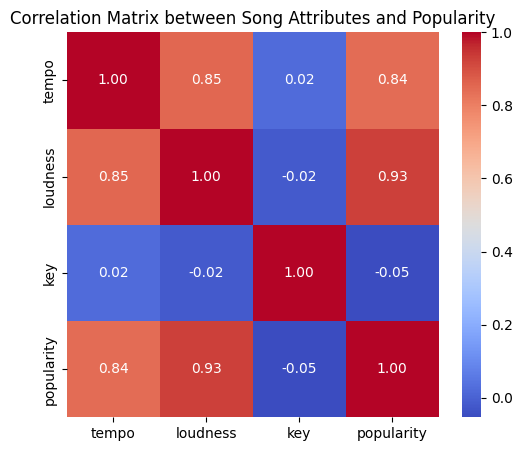

```python
import matplotlib.pyplot as plt
import seaborn as sns

# 1. Tính hệ số tương quan Pearson giữa các thuộc tính
corr = df[['tempo', 'loudness', 'key', 'popularity']].corr()

print("Correlation matrix:")
print(corr)

# 2. Vẽ heatmap để trực quan mối tương quan
plt.figure(figsize=(6,5))
sns.heatmap(corr, annot=True, cmap='coolwarm', fmt=".2f")
plt.title('Correlation Matrix between Song Attributes and Popularity')
plt.show()
```

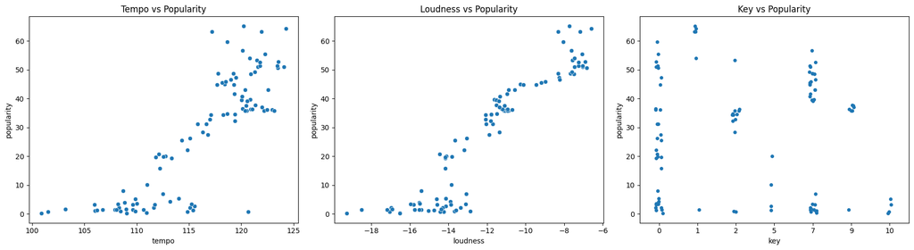

```python
# 3. Vẽ scatter plots để xem quan hệ giữa từng thuộc tính và popularity
fig, axs = plt.subplots(1, 3, figsize=(18,5))

# Scatter tempo vs popularity
sns.scatterplot(data=df, x='tempo', y='popularity', ax=axs[0])
axs[0].set_title('Tempo vs Popularity')

# Scatter loudness vs popularity
sns.scatterplot(data=df, x='loudness', y='popularity', ax=axs[1])
axs[1].set_title('Loudness vs Popularity')

# Scatter key vs popularity (vì key là dạng số rời rạc, dùng stripplot hoặc swarmplot)
sns.stripplot(data=df, x='key', y='popularity', ax=axs[2], jitter=True)
axs[2].set_title('Key vs Popularity')

plt.tight_layout()
plt.show()
```

## **Nhận Xét (trả lời):**

- Tempo và popularity có tương quan dương khá mạnh (0.84):
  - Những bài hát có nhịp độ nhanh hơn thường có xu hướng phổ biến hơn. Điều này phản ánh xu hướng yêu thích nhạc sôi động, dễ bắt tai của người nghe hiện đại.
- Loudness (độ lớn âm thanh) và popularity có hệ số tương quan rất cao (0.93):
  - Bài hát có âm lượng lớn hơn (tức là âm thanh mạnh, sống động hơn) có xu hướng phổ biến hơn. Đây là yếu tố ảnh hưởng lớn đến trải nghiệm cảm xúc người nghe.
- Musical key (tông nhạc) có tương quan rất thấp với popularity (-0.05):
  - Tông nhạc không có ảnh hưởng rõ ràng đến mức độ phổ biến. Việc bài hát ở tông nào không phải là yếu tố quyết định sự yêu thích của người nghe.

# **Question 4**

- How has the average song duration changed over time? Are songs getting shorter or longer?
- Thời lượng trung bình của bài hát đã thay đổi như thế nào theo thời gian? Các bài hát đang trở nên ngắn hơn hay dài hơn?

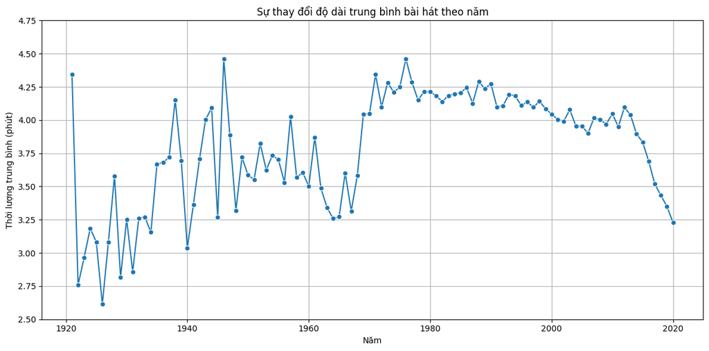

```python
import matplotlib.pyplot as plt
import seaborn as sns

# Tính trung bình thời lượng bài hát theo từng năm (nếu chưa có)
avg_duration_by_year = df.groupby("year")["duration_minutes"].mean().reset_index()

# Vẽ biểu đồ đường
plt.figure(figsize=(12, 6))
sns.lineplot(data=avg_duration_by_year, x="year", y="duration_minutes", marker="o")
plt.title("Sự thay đổi độ dài trung bình bài hát theo năm")
plt.xlabel("Năm")
plt.ylabel("Thời lượng trung bình (phút)")
plt.ylim(2.5, 4.75)
plt.grid(True)
plt.tight_layout()
plt.show()
```

## Question 5:

- Do songs with high acousticness tend to be less popular?
- Các bài hát có độ acousticness cao có xu hướng kém phổ biến hơn không?

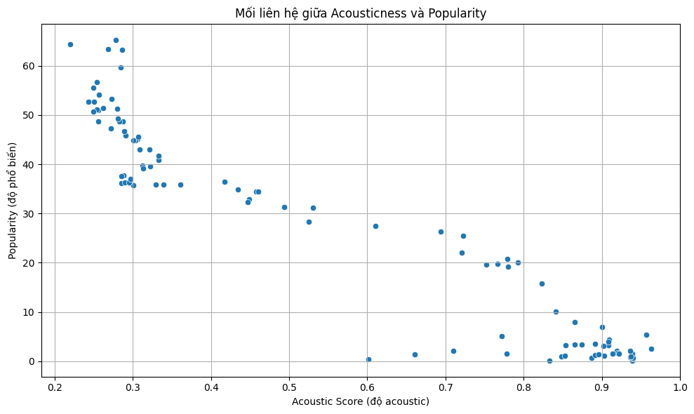

```python
# Đổi tên cột cho đồng nhất
df.rename(columns={"acoustic_ratio": "acoustic_score"}, inplace=True)
# Vẽ biểu đồ scatter giữa độ phổ biến và độ acoustic
plt.figure(figsize=(10, 6))
sns.scatterplot(data=df, x="acoustic_score", y="popularity")
plt.title("Mối liên hệ giữa Acousticness và Popularity")
plt.xlabel("Acoustic Score (độ acoustic)")
plt.ylabel("Popularity (độ phổ biến)")
plt.grid(True)
plt.tight_layout()
plt.show()
```

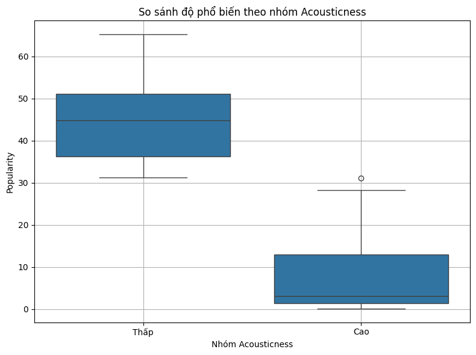

```python
# Phân nhóm acoustic thấp và cao
df["acoustic_group"] = pd.cut(df["acoustic_score"], bins=[0, 0.5, 1], labels=["Thấp", "Cao"])

# Vẽ biểu đồ boxplot để so sánh mức độ phổ biến giữa 2 nhóm acoustic
plt.figure(figsize=(8, 6))
sns.boxplot(data=df, x="acoustic_group", y="popularity")
plt.title("So sánh độ phổ biến theo nhóm Acousticness")
plt.xlabel("Nhóm Acousticness")
plt.ylabel("Popularity")
plt.grid(True)
plt.tight_layout()
plt.show()
```

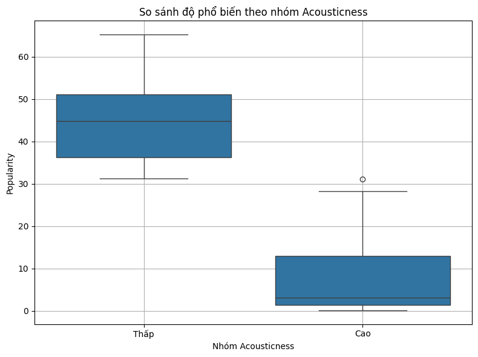

```python
# Phân nhóm acoustic thấp và cao
df["acoustic_group"] = pd.cut(df["acoustic_score"], bins=[0, 0.5, 1], labels=["Thấp", "Cao"])

# Vẽ biểu đồ boxplot để so sánh mức độ phổ biến giữa 2 nhóm acoustic
plt.figure(figsize=(8, 6))
sns.boxplot(data=df, x="acoustic_group", y="popularity")
plt.title("So sánh độ phổ biến theo nhóm Acousticness")
plt.xlabel("Nhóm Acousticness")
plt.ylabel("Popularity")
plt.grid(True)
plt.tight_layout()
plt.show()
```

## **Nhận xét**

- Acousticness đại diện cho mức độ "mộc mạc", không sử dụng hiệu ứng điện tử trong bài hát.
- Những bài hát có acousticness cao thường mang phong cách:
  - Nhẹ nhàng, chậm rãi. Gần với nhạc cổ điển, nhạc dân gian, ballad hoặc hòa tấu. -Trong khi đó, thị trường âm nhạc hiện đại (nhất là nhạc pop, EDM, hip-hop) lại ưa chuộng các bài hát:
  - Có tiết tấu nhanh, sôi động.
  - Sử dụng nhiều hiệu ứng và âm thanh điện tử.
- Điều này giải thích vì sao những bài có acousticness cao thường kén người nghe hơn, dẫn đến mức độ phổ biến (popularity) thấp.

### **5.2 - Reflection**

#### 2. Tính Thực Tiễn Của Phân Tích Dữ Liệu Trong Âm Nhạc

Trước đây, âm nhạc được nhìn nhận nhiều ở khía cạnh cảm xúc hoặc nghệ thuật, nhưng qua bài phân tích này, mình nhận thấy **dữ liệu hoàn toàn có thể dự đoán được mức độ phổ biến của một bài hát**. Những đặc trưng như `energy_level`, `loudness`, `dance_score`... có ảnh hưởng rõ rệt, giúp các nhà sản xuất định hình phong cách và kỹ thuật sản xuất phù hợp với thị trường.

#### 3. Phân Biệt Giữa Giá Trị Nghệ Thuật và Giá Trị Thị Trường

Một bài học sâu sắc là: **giá trị nghệ thuật không đồng nghĩa với mức độ phổ biến**. Những bài hát acoustic hoặc instrumental tuy có chiều sâu, kỹ thuật và cảm xúc cao, nhưng nếu không phù hợp với thị hiếu nghe nhanh – dễ nhớ – bắt tai, thì vẫn có thể không đạt được thành công thương mại. Điều này giúp mình nhìn nhận một cách cân bằng giữa việc làm nhạc vì nghệ thuật và làm nhạc vì thị trường.

#### 4. Tư Duy Phân Tích và Khả Năng Diễn Giải Dữ Liệu

Thông qua việc đọc biểu đồ nhiệt và các chỉ số tương quan, mình rèn luyện được **kỹ năng phân tích định lượng** trong một lĩnh vực tưởng như chỉ cảm tính như âm nhạc. Mình học được cách **diễn giải số liệu thành câu chuyện**, kết nối những con số khô khan với các hiện tượng thực tế như Billboard, Spotify Trends hay chiến lược âm nhạc của các nghệ sĩ lớn.

#### 5. Ứng Dụng Thực Tế Trong Sản Xuất và Định Hướng Nghề Nghiệp

Là một người yêu âm nhạc (hoặc người học về khoa học dữ liệu), việc hiểu được các yếu tố ảnh hưởng đến sự phổ biến của bài hát không chỉ giúp **nâng cao khả năng sản xuất nhạc có định hướng thị trường**, mà còn mở ra nhiều hướng nghề nghiệp mới — ví dụ như **data analyst trong ngành công nghiệp âm nhạc**, tư vấn nghệ sĩ, hoặc phát triển thuật toán gợi ý nhạc cho các nền tảng.